# R Refresher Activities: Key

Christopher M. Loan

2023-02-20

# 1 Set-up

## 1.1 Installing packages

- Open `RStudio` by double clicking the `.Rproj` file
- Use `install.packages()` to install these packages:
  1. `tidyverse`
  2. `rsample`
  3. `rpart`
  4. `rpart.plot`
  5. `vip`
  6. `pdp`

```r
package_name_vector <-
  c('tidyverse',
    'rsample',
    'rpart',
    'rpart.plot',
    'vip',
    'pdp'
  )

#install.packages(package_name_vector)
```

## 1.2 Load Packages

- We will only use packages from `tidyverse` and `rpart.plot` for this example
- Use `library()` to load `tidyverse` and `rpart.plot`
- The other packages are in the examples at the end of the day

```r
library(tidyverse)
library(rpart.plot)
```

## 1.3 Reading in Data

### 1.3.1 From a package

Use `data()` to load the `ptitanic` data set (part of the `rpart.plot` package), then use `head(ptitanic, 4)` to see the first 4 rows

```r
data(ptitanic)
head(ptitanic, 4)
```

```
##   pclass survived    sex     age sibsp parch
## 1    1st survived female 29.0000     0     0
## 2    1st survived   male  0.9167     1     2
## 3    1st     died female  2.0000     1     2
## 4    1st     died   male 30.0000     1     2
```

(we don’t use this data anymore in this exercise, it was just for practice)

### 1.3.2 From a .csv

Let’s load 2 data files:

- Both are in a folder called `data`
- One is called `world_bank_key.csv` — store this object as `key`
- The other is called `se_asia_imputed_world_bank.csv`— store this object as `dat`

**Don’t forget to store the data as an object with `<-`**

```r
# dat / df are short for "data frame"
# they are commonly used names in programming
# I will inevitably slip these in
key <- read.csv('data/world_bank_key.csv')
dat <- read.csv('data/se_asia_imputed_world_bank.csv')
```

Here’s a description of the files:

- `world_bank_key.csv` is a key which links the original variable name and indicator code, with a shorter name.
  - The shorter name is called `janitor_version` because I used a package called `janitor` to clean the `indicator_code` column.
  - the `janitor_version` correspond to the variable names (i.e., column names) in the `se_asia_imputed_world_bank.csv` file.
- `se_asia_imputed_world_bank.csv`
  - yearly observations of several variables
  - variables with minimal missingness were retained
  - the few missing values relied on simple median imputing
  - these are not optimal imputation conditions
  - there is actually some missing data still in the file, but this is only if all years were empty for a given country

# 2 Cleaning Data

## 2.1 Inspecting data

Convert both objects to tibbles and inspect them

```r
dat <- tibble(dat)
key <- tibble(key)
```

## 2.2 Subsetting Data

run the following code to filter your key for only variables in this dataset:

**NOTE:** this key assumes you loaded the imputed data as `dat` and the key as `key`

```r
observed_names <- names(dat)

key_subset <-
  key %>%
  filter(
    janitor_version %in% observed_names
  )
```

**NOTE:** Because `%in%` starts with a `%`, you need back ticks (`), single quotes (’), or double quotes (“) wrapping around it to call the help documentation. Like this:

```
?`%in%`
```

## 2.3 Inspecting Data

Use `dim()` with `key` and `key_subset` to see how much smaller this makes `key_subset`. Now it is managable to look through this.

```r
dim(key)
```

```
## [1] 1442    3
```

```r
dim(key_subset)
```

```
## [1] 32  3
```

# 3 Simple Refreshers

## 3.1 Filtering

Use `key_subset` to find which variable in `dat` corresponds to an `indicator_name` of `Compulsory education, duration (years)`.

**HINT:** we want the one in the column labeled `janitor_version`

```r
key %>%
  filter(
    indicator_name == 'Compulsory education, duration (years)'
  ) %>%
  pull(janitor_version)
```

```
## [1] "se_com_durs"
```

## 3.2 Line Plots

Use `ggplot2` to plot the variable you found over time, and by country.

- in `ggplot(mapping = aes())`
  - set `year` as the `x`-axis
  - set the variable corresponding to `Compulsory education, duration (years)` on the `y`-axis.
  - set `country_name` as the `color`
- use `geom_line()` as our shape, since the values are continuous across time and are known.
- use `labs(y = 'Compulsory education, duration (years)')` in your plot to make a cleaner y-axis title

**HINT:** if your geom_line() is thinner than you’d like aesthetically, try `geom_line(size = 1.5)`. Don’t go too large though, as it will make it harder to determine the value.

```
## Warning: Removed 19 row(s) containing missing values (geom_path).
```

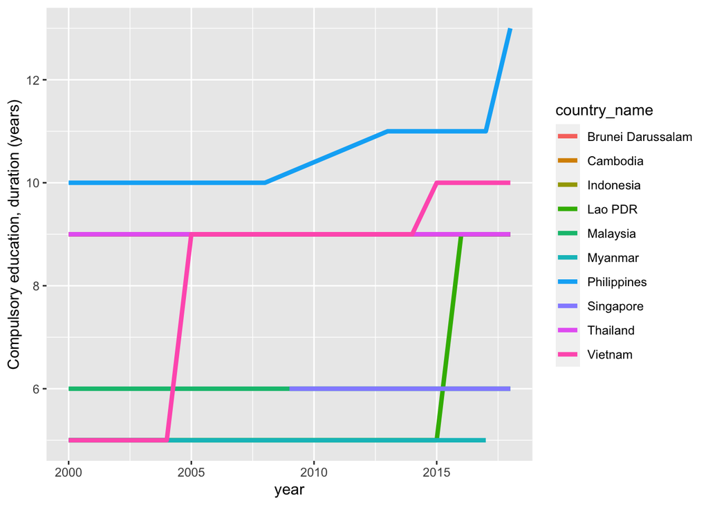

```r
plt <-
  dat %>%
  ggplot(
    aes(
      x = year,
      y = se_com_durs,
      color = country_name,
    )
  ) +
  geom_line(size = 1.5) +
  labs(y = 'Compulsory education, duration (years)')

plt
```

`ggplot2` (should have) gave you a warning message. Something like:

```
Warning message:
Removed 19 row(s) containing missing values (geom_path).
```

It is also very hard to see data for every country.

## 3.3 Investigating the warning:

### 3.3.1 Inspecting Visually

- let’s divide this plot up by `country_name`
- this helps for 2 reasons:
  - it allows you to see each country’s trajectory
  - we can get a guess as to where the missingness is.
- we do this by “facet wrapping”, which makes the same plot within a group several times
- add this code to the end of your plot: `+ facet_wrap(vars(country_name))`

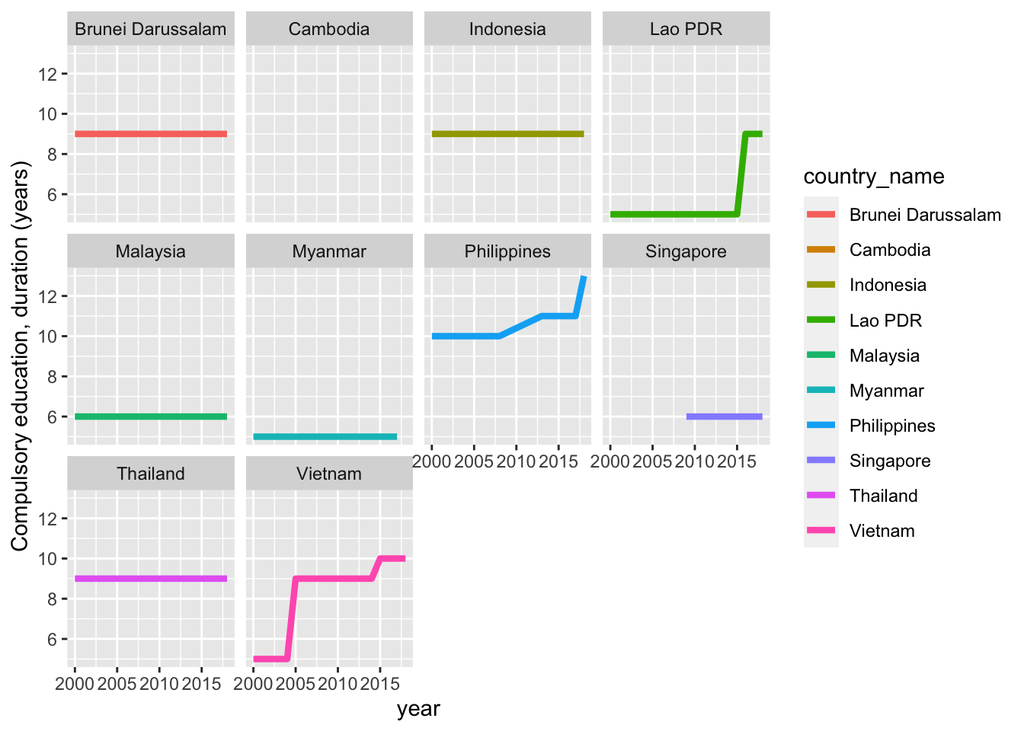

```r
plt + facet_wrap(vars(country_name))
```

Apparently - as we can tell from our `facet_wrap()` call - Cambodia does not report this variable to the World Bank.

### 3.3.2 Inspecting Tabularly

Alternatively, we could have used `filter()` and `if_any()` to subset rows which were missing in one of the 3 variables we used in the plot (see below).

```r
dat %>%
  select(country_name, year, se_com_durs) %>%
  filter(
    if_any(
      # function to apply for filtering
      .fns = is.na
      )
  )
```

```
## # A tibble: 19 × 3
##    country_name  year se_com_durs
##    <chr>        <int>       <int>
##  1 Cambodia      2000          NA
##  2 Cambodia      2001          NA
##  3 Cambodia      2002          NA
##  4 Cambodia      2003          NA
##  5 Cambodia      2004          NA
##  6 Cambodia      2005          NA
##  7 Cambodia      2006          NA
##  8 Cambodia      2007          NA
##  9 Cambodia      2008          NA
## 10 Cambodia      2009          NA
## 11 Cambodia      2010          NA
## 12 Cambodia      2011          NA
## 13 Cambodia      2012          NA
## 14 Cambodia      2013          NA
## 15 Cambodia      2014          NA
## 16 Cambodia      2015          NA
## 17 Cambodia      2016          NA
## 18 Cambodia      2017          NA
## 19 Cambodia      2018          NA
```

# 4 Multi-Step Data Manipulations

## 4.1 Exercise 1

### 4.1.1 Subsetting Rows & Columns; Arranging

- Using `filter(year == 2018)`, subset the years of compulsory education in each country in 2018
- Use `select()` to limit the number of columns in the output to `country_name`, `year`, and `se_com_durs`
- Pipe (`%>%`) the filtered data to `arrange(desc(se_com_durs))` to show see which country has the highest current value
- Pipe this to `drop_na(se_com_durs)` to eliminate countries with missing data in this variable
- store this as an object called `compulsory_edu_2018`

```r
compulsory_edu_2018 <-
  dat %>%
  filter(year == 2018) %>%
  select(country_name, year, se_com_durs) %>%
  arrange(desc(se_com_durs)) %>%
  drop_na(se_com_durs)
```

- store `compulsory_edu_2018` as a `tibble()`.
- inspect that object

```r
compulsory_edu_2018 <- tibble(compulsory_edu_2018)
compulsory_edu_2018
```

```
## # A tibble: 8 × 3
##   country_name       year se_com_durs
##   <chr>             <int>       <int>
## 1 Philippines        2018          13
## 2 Vietnam            2018          10
## 3 Brunei Darussalam  2018           9
## 4 Indonesia          2018           9
## 5 Lao PDR            2018           9
## 6 Thailand           2018           9
## 7 Malaysia           2018           6
## 8 Singapore          2018           6
```

## 4.2 Exercise 2

### 4.2.1 Filtering & Pulling

Find the variable which corresponds to `Government expenditure on education, total (% of GDP)`.

Last time: You could do this any way. Perhaps you inspected `key_subset` and found the variable. This time:

- Get the `janitor_version` which corresponds to `Government expenditure on education, total (% of GDP)` with code
- Do this by filling the arguments in this code: `key_subset %>% filter() %>% pull()`

```r
key_subset %>%
  filter(
    indicator_name == 'Government expenditure on education, total (% of GDP)'
  ) %>%
  pull(janitor_version)
```

[output not shown]

### 4.2.2 Create a line plot of Government expenditure on education, total (% of GDP) vs. year

- Add points to your `geom_line()` as well
- Be sure to label the y axis with `labs(y = '% of GDP on education')`
- Use `?labs()` to figure out how to add a title.
- Write your own title for the plot.

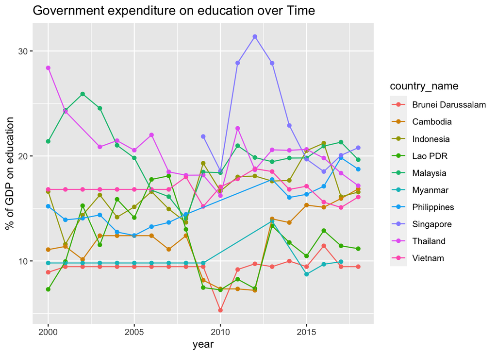

```r
dat %>%
  ggplot(
    aes(
      x = year,
      y = se_xpd_totl_gb_zs,
      fill = country_name,
      color = country_name
    )
  ) +
  geom_point() +
  geom_line() +
  labs(
    y = '% of GDP on education',
    title = 'Government expenditure on education over Time'
    )
```

# 5 Diving Deeper

## 5.1 Using Documentation to Understand Functions

Explain what this code is doing:

```
dat %>%
  group_by(country_name) %>%
  summarize(
    mean_edu_expendature = mean(se_xpd_totl_gb_zs, na.rm = T)
  )
```

- Call help documentation if you don’t know a variable name (e.g., `?summarize()`)
- Try to figure it out from the help documentation before you run it
- Rewrite it in your own words here:

copy the code you just described, store the object as `education_expen`

```r
education_expen <-
  dat %>%
  group_by(country_name) %>%
  summarize(
    mean_edu_expendature = mean(se_xpd_totl_gb_zs, na.rm = T)
  )
```

## 5.2 More Visualization Practice

- Use a column plot `geom_col()` to visualize
  - the `mean_edu_expendature` on the `x`-axis
  - the `country_name` on the `y`-axis

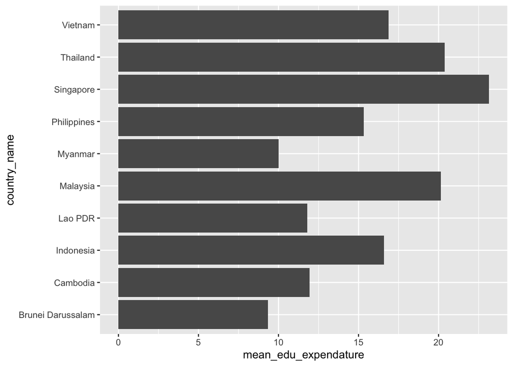

```r
education_expen %>%
  ggplot(
    aes(
      y = country_name,
      x = mean_edu_expendature
    )
  ) +
  geom_col()
```

This doesn’t look very nice, yet, but it can (see the “extra time” section)

I provide some formatting (and error bars) below:

# 6 Explorations (if extra time)

With any remaining time:

- Run the following code to make a nicer looking plot
- Explore the help documentation for functions/arguments you do not know - e.g., `?fct_reorder()`
- Make your own tweaks to this plot, or make another

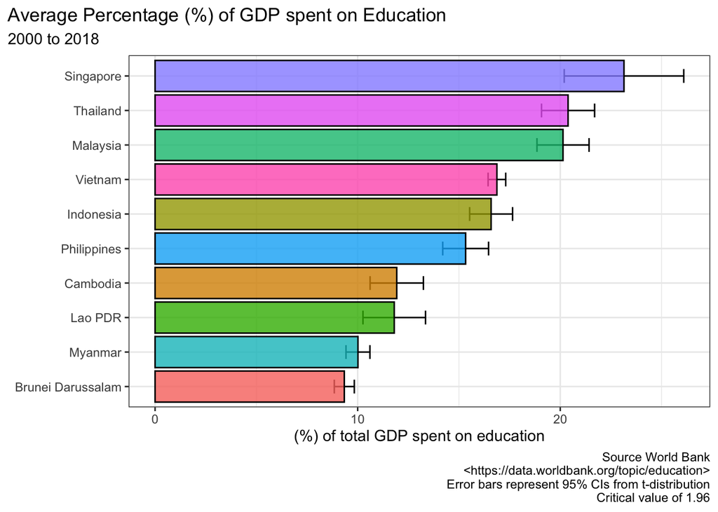

```r
dat %>%
  group_by(country_name) %>%
  summarize(
    mean_edu_expendature = mean(se_xpd_totl_gb_zs, na.rm = T),
    sd = sd(se_xpd_totl_gb_zs, na.rm = T),
    se = sd/sqrt(n()),
    lower_ci = mean_edu_expendature - 1.96*se,
    upper_ci = mean_edu_expendature + 1.96*se
  ) %>%
 mutate(
    country_name_ordered =
# fct_reorder allows us to order country name by a variable
# if we use the ordered version, the plot looks nicer
      fct_reorder(.f = country_name, .x = mean_edu_expendature)
  ) %>%
   ggplot(
    aes(
      y = country_name_ordered,
      x = mean_edu_expendature,
      xmin = lower_ci,
      xmax = upper_ci,
      fill = country_name
    )
  ) +
  geom_errorbar(width = 0.4, color = 'black') +
  geom_col(
    alpha = 0.8,
    color = 'black',
    show.legend = FALSE
  ) +
  theme_bw() +
  labs(
    y = element_blank(),
    x = '(%) of total GDP spent on education',
    fill = 'Country',
    title = 'Average Percentage (%) of GDP spent on Education',
    subtitle = paste0(min(dat$year), ' to ', max(dat$year)),
    caption = 'Source World Bank\n<https://data.worldbank.org/topic/education>\nError bars represent 95% CIs from t-distribution\nCritical value of 1.96'
    ) +
  theme(
    plot.title.position = 'plot',
    plot.caption.position = 'plot'
  )
```